**GitHub Repository:** https://github.com/sadieakel/GSB-544/tree/master/Labs/Lab_6

# Lab 6

Author

Sadie Akel

```python
import pandas as pd
import numpy as np
from sklearn.pipeline import Pipeline
from sklearn.preprocessing import StandardScaler, OneHotEncoder, PolynomialFeatures
from sklearn.linear_model import LinearRegression, Ridge, Lasso, ElasticNet
from sklearn.model_selection import train_test_split
from sklearn.metrics import r2_score
from sklearn.pipeline import Pipeline
from sklearn.compose import make_column_selector, ColumnTransformer
from sklearn.model_selection import cross_val_score
from sklearn.model_selection import GridSearchCV
import matplotlib.pyplot as plt
```

## Part 0: Data Loading and Cleaning

```python
hitters = pd.read_csv("~/Desktop/GSB 544/Labs/Lab_6/Hitters.csv", sep=",")
hitters.head()
```

|  | AtBat | Hits | HmRun | Runs | RBI | Walks | Years | CAtBat | CHits | CHmRun | CRuns | CRBI | CWalks | League | Division | PutOuts | Assists | Errors | Salary | NewLeague |
| --- | --- | --- | --- | --- | --- | --- | --- | --- | --- | --- | --- | --- | --- | --- | --- | --- | --- | --- | --- | --- |
| 0 | 293 | 66 | 1 | 30 | 29 | 14 | 1 | 293 | 66 | 1 | 30 | 29 | 14 | A | E | 446 | 33 | 20 | NaN | A |
| 1 | 315 | 81 | 7 | 24 | 38 | 39 | 14 | 3449 | 835 | 69 | 321 | 414 | 375 | N | W | 632 | 43 | 10 | 475.0 | N |
| 2 | 479 | 130 | 18 | 66 | 72 | 76 | 3 | 1624 | 457 | 63 | 224 | 266 | 263 | A | W | 880 | 82 | 14 | 480.0 | A |
| 3 | 496 | 141 | 20 | 65 | 78 | 37 | 11 | 5628 | 1575 | 225 | 828 | 838 | 354 | N | E | 200 | 11 | 3 | 500.0 | N |
| 4 | 321 | 87 | 10 | 39 | 42 | 30 | 2 | 396 | 101 | 12 | 48 | 46 | 33 | N | E | 805 | 40 | 4 | 91.5 | N |

First step in our data cleaning is to remove NaN values (most NaN values are in the Salary column which is the column we are looking to predict). Additionally, we will remove any columns with mostly NaN values.

```python
# Get rid of columns with mostly NaN values
good_cols = hitters.isna().sum() < 100
hitters = hitters.loc[:,good_cols]

# Drop other NAs
hitters = hitters.dropna()
```

Now, we make sure that our variable typesare what we want:

```python
hitters.info()
```

```
<class 'pandas.core.frame.DataFrame'>
Index: 263 entries, 1 to 321
Data columns (total 20 columns):
 #   Column     Non-Null Count  Dtype
---  ------     --------------  -----
 0   AtBat      263 non-null    int64
 1   Hits       263 non-null    int64
 2   HmRun      263 non-null    int64
 3   Runs       263 non-null    int64
 4   RBI        263 non-null    int64
 5   Walks      263 non-null    int64
 6   Years      263 non-null    int64
 7   CAtBat     263 non-null    int64
 8   CHits      263 non-null    int64
 9   CHmRun     263 non-null    int64
 10  CRuns      263 non-null    int64
 11  CRBI       263 non-null    int64
 12  CWalks     263 non-null    int64
 13  League     263 non-null    object
 14  Division   263 non-null    object
 15  PutOuts    263 non-null    int64
 16  Assists    263 non-null    int64
 17  Errors     263 non-null    int64
 18  Salary     263 non-null    float64
 19  NewLeague  263 non-null    object
dtypes: float64(1), int64(16), object(3)
memory usage: 43.1+ KB
```

Everything looks good! Now we can proceed with creating our models.

## Part 1: Different Model Specs

```python
X = hitters.drop(["Salary"], axis = 1)
y = hitters["Salary"]
```

### A: Regression without regularization

1. Creating the pipeline

```python
ct_dummify = ColumnTransformer(
  [
    ("dummify",
    OneHotEncoder(sparse_output = False, handle_unknown='ignore'),
    make_column_selector(dtype_include=object)),
    ("standardize",
    StandardScaler(),
    make_column_selector(dtype_include=np.number))
  ],
  remainder = "passthrough").set_output(transform = "pandas")
```

```python
lr_all_vars_pipeline= Pipeline(
    [("dummify", ct_dummify),
    ("linear regression", LinearRegression())]
)
```

2. Fitting the pipeline to the full dataset

```python
all_vars_fit = lr_all_vars_pipeline.fit(X, y)
```

```python
feature_names = lr_all_vars_pipeline.named_steps['dummify'].get_feature_names_out() #used google for the .get_feature_names_out() function
coefs = lr_all_vars_pipeline.named_steps['linear regression'].coef_

coef_df = pd.DataFrame({
    'feature': feature_names,
    'coefficient': coefs
})

coef_df = coef_df.sort_values(by='coefficient', ascending=False)

print(coef_df)
```

```
                 feature  coefficient
16    standardize__CRuns   480.747135
7      standardize__Hits   337.830479
17     standardize__CRBI   260.689886
11    standardize__Walks   135.073897
14    standardize__CHits    86.687617
19  standardize__PutOuts    78.761296
2    dummify__Division_E    58.424623
20  standardize__Assists    53.732490
8     standardize__HmRun    37.853837
1      dummify__League_N    31.299712
4   dummify__NewLeague_A    12.381163
5   dummify__NewLeague_N   -12.381163
15   standardize__CHmRun   -14.181723
12    standardize__Years   -16.693359
21   standardize__Errors   -22.160862
10      standardize__RBI   -26.994984
0      dummify__League_A   -31.299712
3    dummify__Division_W   -58.424623
9      standardize__Runs   -60.572479
18   standardize__CWalks  -213.892259
6     standardize__AtBat  -291.094556
13   standardize__CAtBat  -391.038655
```

3. Using cross validation to estimate the MSE

```python
scores=-cross_val_score(lr_all_vars_pipeline, X, y, cv = 5, scoring = 'neg_mean_squared_error')
print(scores, scores.mean())
```

```
[ 76408.91409134 129937.76968228  79976.48830477 204818.01839674
 114540.36111572] 121136.31031816891
```

Shows the cross-validated MSE of this model is 121136.31031816888.

### B: Ridge Regression

1. Pipeline that includes all explanatory variables and performs regular Ridge regression:

```python
def create_pipeline(type):
    all_vars_pipeline= Pipeline(
        [("dummify", ct_dummify),
        ("regression", type())]
    )
    return all_vars_pipeline
```

```python
def create_pipeline_alpha(type, x):
    all_vars_pipeline= Pipeline(
        [("dummify", ct_dummify),
        ("regression", type(alpha=x))]
    )
    return all_vars_pipeline
```

```python
ridge_pipeline=create_pipeline(Ridge)
ridge_pipeline.fit(X,y)
```

```
Pipeline(steps=[('dummify',
                 ColumnTransformer(remainder='passthrough',
                                   transformers=[('dummify',
                                                  OneHotEncoder(handle_unknown='ignore',
                                                                sparse_output=False),
                                                  <sklearn.compose._column_transformer.make_column_selector object at 0x14dd674d0>),
                                                 ('standardize',
                                                  StandardScaler(),
                                                  <sklearn.compose._column_transformer.make_column_selector object at 0x1477c51d0>)])),
                ('regression', Ridge())])
```

2. Using cross validation to tune the lambda hyperparameter:

```python
lambdas = {'regression__alpha': (0.0001, 0.001, 0.01, 0.1, 1, 10, 50, 100, 500, 1000)}
gscv = GridSearchCV(ridge_pipeline, lambdas, cv = 5, scoring='neg_mean_squared_error')
```

```python
gscv_fitted = gscv.fit(X, y)
gscv_fitted.cv_results_['mean_test_score']
pd.DataFrame(data = {"alphas": (0.0001, 0.001, 0.01, 0.1, 1, 10, 50, 100, 500, 1000), "scores": gscv_fitted.cv_results_['mean_test_score']})
```

|  | alphas | scores |
| --- | --- | --- |
| 0 | 0.0001 | -121135.119780 |
| 1 | 0.0010 | -121124.458592 |
| 2 | 0.0100 | -121022.903286 |
| 3 | 0.1000 | -120343.621067 |
| 4 | 1.0000 | -119144.432677 |
| 5 | 10.0000 | -119348.984776 |
| 6 | 50.0000 | -120244.968387 |
| 7 | 100.0000 | -120716.435589 |
| 8 | 500.0000 | -126511.155115 |
| 9 | 1000.0000 | -134876.333803 |

Lambda=1 seems to be the best lambda score

3. Interpeting coefficients:

```python
ridge_pipeline_1=create_pipeline_alpha(Ridge, 1)
ridge_pipeline_1.fit(X,y)
```

```
Pipeline(steps=[('dummify',
                 ColumnTransformer(remainder='passthrough',
                                   transformers=[('dummify',
                                                  OneHotEncoder(handle_unknown='ignore',
                                                                sparse_output=False),
                                                  <sklearn.compose._column_transformer.make_column_selector object at 0x14dd674d0>),
                                                 ('standardize',
                                                  StandardScaler(),
                                                  <sklearn.compose._column_transformer.make_column_selector object at 0x1477c51d0>)])),
                ('regression', Ridge(alpha=1))])
```

```python
feature_names = ridge_pipeline_1.named_steps['dummify'].get_feature_names_out()
coefs = ridge_pipeline_1.named_steps['regression'].coef_

ridge_coef_df = pd.DataFrame({
    'feature': feature_names,
    'coefficient': coefs
})

ridge_coef_df = ridge_coef_df.sort_values(by='coefficient', ascending=False)

print(ridge_coef_df)
```

```
                 feature  coefficient
16    standardize__CRuns   320.412169
7      standardize__Hits   296.645050
17     standardize__CRBI   160.386784
14    standardize__CHits   126.659607
11    standardize__Walks   124.407173
19  standardize__PutOuts    78.623656
2    dummify__Division_E    60.015595
20  standardize__Assists    47.462597
15   standardize__CHmRun    39.070924
1      dummify__League_N    30.438855
8     standardize__HmRun    18.100592
4   dummify__NewLeague_A    13.111282
10      standardize__RBI    -9.113295
5   dummify__NewLeague_N   -13.111282
21   standardize__Errors   -23.724190
9      standardize__Runs   -29.339406
0      dummify__League_A   -30.438855
12    standardize__Years   -38.667748
3    dummify__Division_W   -60.015595
18   standardize__CWalks  -184.423611
13   standardize__CAtBat  -225.406548
6     standardize__AtBat  -270.686441
```

16 standardize__CRuns 320.412169 7 standardize__Hits 296.645050 6 standardize__AtBat -270.686441

For each increase in one standard deviaton of Career runs we expect Salary to increase by about 320 thousand dollars, and for each increase in one standard deviation of hits in 1986 we expect Salary to increase by 297 thousand dollars. For each increase in one standard deviation in At Bats in 1986, we expect Salary to decrease by 270 thousand dollars.

4. MSE if this pipeline was used to predict 1986 salary

```python
scores_ridge=-cross_val_score(ridge_pipeline_1, X, y, cv = 5, scoring = 'neg_mean_squared_error')
print(scores_ridge, scores_ridge.mean())
```

```
[ 76881.86322107 133524.06955313  78222.03719222 197338.56496953
 109755.62844862] 119144.43267691585
```

We expect the MSE to be 119144.4326769158.

### C: Lasso Regression

1. Creating the pipeline

```python
lasso_pipeline=create_pipeline(Lasso)
lasso_pipeline.fit(X,y)
```

```
Pipeline(steps=[('dummify',
                 ColumnTransformer(remainder='passthrough',
                                   transformers=[('dummify',
                                                  OneHotEncoder(handle_unknown='ignore',
                                                                sparse_output=False),
                                                  <sklearn.compose._column_transformer.make_column_selector object at 0x14dd674d0>),
                                                 ('standardize',
                                                  StandardScaler(),
                                                  <sklearn.compose._column_transformer.make_column_selector object at 0x1477c51d0>)])),
                ('regression', Lasso())])
```

2. Using cross validation to tune the hyperparameter

```python
lambdas = {'regression__alpha': (0.0001, 0.001, 0.01, 0.1, 1, 10, 50, 100, 500, 1000)}
gscv2 = GridSearchCV(lasso_pipeline, lambdas, cv = 5, scoring='neg_mean_squared_error')
```

```python
gscv2_fitted = gscv2.fit(X, y)
gscv2_fitted.cv_results_['mean_test_score']
pd.DataFrame(data = {"alphas": (0.0001, 0.001, 0.01, 0.1, 1, 10, 50, 100, 500, 1000), "scores": gscv2_fitted.cv_results_['mean_test_score']})
```

|  | alphas | scores |
| --- | --- | --- |
| 0 | 0.0001 | -120997.134215 |
| 1 | 0.0010 | -120994.179815 |
| 2 | 0.0100 | -120964.764686 |
| 3 | 0.1000 | -120682.252637 |
| 4 | 1.0000 | -119761.587407 |
| 5 | 10.0000 | -121828.141333 |
| 6 | 50.0000 | -129089.367547 |
| 7 | 100.0000 | -143755.162381 |
| 8 | 500.0000 | -205647.170400 |
| 9 | 1000.0000 | -205647.170400 |

Optimal lambda is 1.

3. Fitting the pipeline with the chosen lambda to the entire dataset

```python
lasso_pipeline_1=create_pipeline_alpha(Lasso, 1)
lasso_pipeline_1.fit(X,y)
```

```
Pipeline(steps=[('dummify',
                 ColumnTransformer(remainder='passthrough',
                                   transformers=[('dummify',
                                                  OneHotEncoder(handle_unknown='ignore',
                                                                sparse_output=False),
                                                  <sklearn.compose._column_transformer.make_column_selector object at 0x14dd674d0>),
                                                 ('standardize',
                                                  StandardScaler(),
                                                  <sklearn.compose._column_transformer.make_column_selector object at 0x1477c51d0>)])),
                ('regression', Lasso(alpha=1))])
```

```python
feature_names = lasso_pipeline_1.named_steps['dummify'].get_feature_names_out()
coefs = lasso_pipeline_1.named_steps['regression'].coef_

lasso_coef_df = pd.DataFrame({
    'feature': feature_names,
    'coefficient': coefs
})

lasso_coef_df = lasso_coef_df.sort_values(by='coefficient', ascending=False)

print(lasso_coef_df)
```

```
                 feature   coefficient
16    standardize__CRuns  3.755655e+02
7      standardize__Hits  3.043595e+02
17     standardize__CRBI  1.926109e+02
11    standardize__Walks  1.206953e+02
2    dummify__Division_E  1.144130e+02
19  standardize__PutOuts  7.876037e+01
20  standardize__Assists  4.199668e+01
15   standardize__CHmRun  1.422599e+01
8     standardize__HmRun  1.112702e+01
1      dummify__League_N  9.974641e-14
10      standardize__RBI -0.000000e+00
14    standardize__CHits  0.000000e+00
4   dummify__NewLeague_A  0.000000e+00
5   dummify__NewLeague_N -0.000000e+00
3    dummify__Division_W -2.078929e-11
21   standardize__Errors -1.847938e+01
9      standardize__Runs -2.496651e+01
12    standardize__Years -3.494815e+01
0      dummify__League_A -3.582607e+01
13   standardize__CAtBat -1.626398e+02
18   standardize__CWalks -1.896446e+02
6     standardize__AtBat -2.823710e+02
```

16 standardize__CRuns 3.755655e+02 7 standardize__Hits 3.043595e+02 6 standardize__AtBat -2.823710e+02

For each increase in one standard deviaton of Career runs we expect Salary to increase by about 376 thousand dollars, and for each increase in one standard deviation of hits in 1986 we expect Salary to increase by 304 thousand dollars. For each increase in one standard deviation in At Bats in 1986, we expect Salary to decrease by 282 thousand dollars.

```python
scores_lasso=-cross_val_score(lasso_pipeline_1, X, y, cv = 5, scoring = 'neg_mean_squared_error')
print(scores_lasso, scores_lasso.mean())
```

```
[ 75612.27882884 135042.28385378  79230.76998299 198789.0287087
 110133.57566276] 119761.58740741308
```

We expect the MSE to be 119761.58740741308.

### D: Elastic Net

1. Creating the Pipeline:

```python
elastic_pipeline=create_pipeline(ElasticNet)
elastic_pipeline.fit(X,y)
```

```
Pipeline(steps=[('dummify',
                 ColumnTransformer(remainder='passthrough',
                                   transformers=[('dummify',
                                                  OneHotEncoder(handle_unknown='ignore',
                                                                sparse_output=False),
                                                  <sklearn.compose._column_transformer.make_column_selector object at 0x14dd674d0>),
                                                 ('standardize',
                                                  StandardScaler(),
                                                  <sklearn.compose._column_transformer.make_column_selector object at 0x1477c51d0>)])),
                ('regression', ElasticNet())])
```

2. Using cross validation to tune the pipeline:

```python
parameters= {
    'regression__alpha': (0.0001, 0.001, 0.01, 0.1, 1, 10, 50, 100, 500, 1000),
    'regression__l1_ratio': (0.01, 0.1, 0.2, 0.3, 0.4, 0.5, 0.6, 0.7, 0.8, 0.9, 0.99)
}

gscv3 = GridSearchCV(elastic_pipeline, parameters, cv = 5, scoring='neg_mean_squared_error')
```

```python
gscv3_fitted = gscv3.fit(X, y)
print(gscv3_fitted.best_score_, gscv3_fitted.best_params_)
```

```
-118959.30308411301 {'regression__alpha': 0.01, 'regression__l1_ratio': 0.01}
```

Cross validation showed that the optimal lambda value is 0.01, and the optimal l1_ratio is 0.01.

3. Fitting the tuned pipeline to the full dataset:

```python
elastic_spec_pipeline= Pipeline(
    [("dummify", ct_dummify),
    ("elastic net", ElasticNet(alpha=0.01, l1_ratio=0.01))]
)
```

```python
elastic_spec_pipeline.fit(X,y)
```

```
Pipeline(steps=[('dummify',
                 ColumnTransformer(remainder='passthrough',
                                   transformers=[('dummify',
                                                  OneHotEncoder(handle_unknown='ignore',
                                                                sparse_output=False),
                                                  <sklearn.compose._column_transformer.make_column_selector object at 0x14dd674d0>),
                                                 ('standardize',
                                                  StandardScaler(),
                                                  <sklearn.compose._column_transformer.make_column_selector object at 0x1477c51d0>)])),
                ('elastic net', ElasticNet(alpha=0.01, l1_ratio=0.01))])
```

```python
feature_names = elastic_spec_pipeline.named_steps['dummify'].get_feature_names_out()
coefs = elastic_spec_pipeline.named_steps['elastic net'].coef_

elastic_coef_df = pd.DataFrame({
    'feature': feature_names,
    'coefficient': coefs
})

elastic_coef_df = elastic_coef_df.sort_values(by='coefficient', ascending=False)

print(elastic_coef_df)
```

```
                 feature  coefficient
7      standardize__Hits   250.557145
16    standardize__CRuns   227.793187
14    standardize__CHits   123.751967
17     standardize__CRBI   123.239568
11    standardize__Walks   112.039137
19  standardize__PutOuts    77.986773
2    dummify__Division_E    60.807601
15   standardize__CHmRun    55.539969
20  standardize__Assists    41.530568
1      dummify__League_N    29.075285
4   dummify__NewLeague_A    12.409998
8     standardize__HmRun     5.504677
10      standardize__RBI     1.790215
9      standardize__Runs    -7.201308
5   dummify__NewLeague_N   -12.410002
21   standardize__Errors   -24.743157
0      dummify__League_A   -29.075284
12    standardize__Years   -49.430999
3    dummify__Division_W   -60.807603
13   standardize__CAtBat  -123.151166
18   standardize__CWalks  -156.861894
6     standardize__AtBat  -233.842932
```

7 standardize__Hits 250.557145 16 standardize__CRuns 227.793187 6 standardize__AtBat -233.842932

For each increase in one standard deviaton of Career runs we expect Salary to increase by about 228 thousand dollars, and for each increase in one standard deviation of hits in 1986 we expect Salary to increase by 251 thousand dollars. For each increase in one standard deviation in At Bats in 1986, we expect Salary to decrease by 234 thousand dollars.

4. Expected MSE

```python
scores_elastic=-cross_val_score(elastic_spec_pipeline, X, y, cv = 5, scoring = 'neg_mean_squared_error')
print(scores_elastic, scores_elastic.mean())
```

```
[ 75978.30572822 137096.03456867  77545.98826029 196007.06287228
 108169.1239911 ] 118959.30308411301
```

The expected MSE is 118959.30308411302.

## Part 2: Variable Selection

From the coefficients in the models tested, I claim that the most important variable is Career Runs.

The 5 most important numeric variables are: Career runs, Hits in 1986, Career RBI, At Bat in 1986, and Career Walks.

The most important categorical variable is Division.

We will now explore the previous models using only these variables.

### 1: Using only the best numeric variable (Career Runs)

```python
ct_select_one = ColumnTransformer(
  [
    ("select", StandardScaler(), ["CRuns"])
  ],
  remainder = "drop")
```

```python
lr_pipeline_cruns= Pipeline(
    [("select", ct_select_one),
    ("regression", LinearRegression())]
)

ridge_pipeline_cruns= Pipeline(
    [("select", ct_select_one),
    ("regression", Ridge())]
)

lasso_pipeline_cruns= Pipeline(
    [("select", ct_select_one),
    ("regression", Lasso())]
)

elastic_pipeline_cruns= Pipeline(
    [("select", ct_select_one),
    ("regression", ElasticNet())]
)

lr_pipeline_cruns.fit(X,y)
ridge_pipeline_cruns.fit(X,y)
lasso_pipeline_cruns.fit(X,y)
elastic_pipeline_cruns.fit(X,y)
```

```
Pipeline(steps=[('select',
                 ColumnTransformer(transformers=[('select', StandardScaler(),
                                                  ['CRuns'])])),
                ('regression', ElasticNet())])
```

```python
parameters= {
    'regression__alpha': (0.0001, 0.001, 0.01, 0.1, 1, 10, 50, 100),
    'regression__l1_ratio': (0.01, 0.1, 0.2, 0.3, 0.4, 0.5, 0.6, 0.7, 0.8, 0.9, 0.99)
}

lambdas = {'regression__alpha': (0.0001, 0.001, 0.01, 0.1, 1, 10, 50, 100)}
gscv4 = GridSearchCV(ridge_pipeline_cruns, lambdas, cv = 5, scoring='neg_mean_squared_error')
gscv5= GridSearchCV(lasso_pipeline_cruns, lambdas, cv = 5, scoring='neg_mean_squared_error')
gscv6= GridSearchCV(elastic_pipeline_cruns, parameters, cv = 5, scoring='neg_mean_squared_error')
```

```python
gscv4_fitted = gscv4.fit(X, y)
gscv5_fitted = gscv5.fit(X, y)
gscv6_fitted = gscv6.fit(X, y)
```

```python
scores_cruns = cross_val_score(lr_pipeline_cruns, X, y, cv=5, scoring='neg_mean_squared_error')
print(scores_cruns.mean())
print(gscv4_fitted.best_score_, gscv4_fitted.best_params_)
print(gscv5_fitted.best_score_, gscv5_fitted.best_params_)
print(gscv6_fitted.best_score_, gscv6_fitted.best_params_)
```

```
-143812.9359162973
-143658.5173685888 {'regression__alpha': 10}
-143793.4491585397 {'regression__alpha': 10}
-143655.07604766646 {'regression__alpha': 0.1, 'regression__l1_ratio': 0.5}
```

Elastic Net performed the best on only one numeric variable with an MSE of 143655.07604766646, lambda=0.1, l1 ratio=0.5

### 2: Using 5 best numeric variables

```python
ct_select_5 = ColumnTransformer(
  [
    ("select", StandardScaler(), ["CRuns", "Hits", "CRBI", "AtBat", "CWalks"])
  ],
  remainder = "drop")
```

```python
lr_pipeline_5= Pipeline(
    [("select", ct_select_5),
    ("regression", LinearRegression())]
)

ridge_pipeline_5= Pipeline(
    [("select", ct_select_5),
    ("regression", Ridge())]
)

lasso_pipeline_5= Pipeline(
    [("select", ct_select_5),
    ("regression", Lasso())]
)

elastic_pipeline_5= Pipeline(
    [("select", ct_select_5),
    ("regression", ElasticNet())]
)

lr_pipeline_5.fit(X,y)
ridge_pipeline_5.fit(X,y)
lasso_pipeline_5.fit(X,y)
elastic_pipeline_5.fit(X,y)
```

```
Pipeline(steps=[('select',
                 ColumnTransformer(transformers=[('select', StandardScaler(),
                                                  ['CRuns', 'Hits', 'CRBI',
                                                   'AtBat', 'CWalks'])])),
                ('regression', ElasticNet())])
```

```python
parameters= {
    'regression__alpha': (0.0001, 0.001, 0.01, 0.1, 1, 10, 50, 100),
    'regression__l1_ratio': (0.01, 0.1, 0.2, 0.3, 0.4, 0.5, 0.6, 0.7, 0.8, 0.9, 0.99)
}

lambdas = {'regression__alpha': (0.0001, 0.001, 0.01, 0.1, 1, 10, 50, 100)}
fivebest1 = GridSearchCV(ridge_pipeline_5, lambdas, cv = 5, scoring='neg_mean_squared_error')
fivebest2= GridSearchCV(lasso_pipeline_5, lambdas, cv = 5, scoring='neg_mean_squared_error')
fivebest3= GridSearchCV(elastic_pipeline_5, parameters, cv = 5, scoring='neg_mean_squared_error')
```

```python
fivebest1_fitted = fivebest1.fit(X, y)
fivebest2_fitted = fivebest2.fit(X, y)
fivebest3_fitted = fivebest3.fit(X, y)
```

```python
scores_5 = cross_val_score(lr_pipeline_5, X, y, cv=5, scoring='neg_mean_squared_error')
print(scores_5.mean())
print(fivebest1_fitted.best_score_, fivebest1_fitted.best_params_)
print(fivebest2_fitted.best_score_, fivebest2_fitted.best_params_)
print(fivebest3_fitted.best_score_, fivebest3_fitted.best_params_)
```

```
-125502.85287637592
-125142.78764099171 {'regression__alpha': 1}
-125289.89426304451 {'regression__alpha': 1}
-124986.74440429464 {'regression__alpha': 0.01, 'regression__l1_ratio': 0.01}
```

Elastic Net performs the best on these variables with lambda value 0.01, ratio 0.01, and an MSE of 124986.74440429464.

```python
ct_dummify = ColumnTransformer(
  [
    ("dummify", OneHotEncoder(sparse_output = False, handle_unknown='ignore'), ["Division"]),
    ("select", StandardScaler(), ["CRuns", "Hits", "CRBI", "AtBat", "CWalks"])
  ],
  remainder = "drop").set_output(transform = "pandas")
```

```python
ct_int = ColumnTransformer(
    [
    ("CRunsInt", PolynomialFeatures(interaction_only=True), ["select__CRuns", "dummify__Division_E"]),
    ("HitsInt", PolynomialFeatures(interaction_only=True), ["select__Hits", "dummify__Division_E"]),
    ("CRBIInt", PolynomialFeatures(interaction_only=True), ["select__CRBI", "dummify__Division_E"]),
    ("CWalks", PolynomialFeatures(interaction_only=True), ["select__CWalks", "dummify__Division_E"])
    ],
    remainder="drop"
).set_output(transform = "pandas")
```

```python
lr_pipeline_int= Pipeline(
    [("dummify", ct_dummify),
    ("interaction", ct_int),
    ("regression", LinearRegression())]
)

ridge_pipeline_int= Pipeline(
    [("dummify", ct_dummify),
    ("interaction", ct_int),
    ("regression", Ridge())]
)

lasso_pipeline_int= Pipeline(
    [("dummify", ct_dummify),
    ("interaction", ct_int),
    ("regression", Lasso())]
)

elastic_pipeline_int= Pipeline(
    [("dummify", ct_dummify),
    ("interaction", ct_int),
    ("regression", ElasticNet())]
)
```

```python
lr_pipeline_int.fit(X,y)
ridge_pipeline_int.fit(X,y)
lasso_pipeline_int.fit(X,y)
elastic_pipeline_int.fit(X,y)
```

```
Pipeline(steps=[('dummify',
                 ColumnTransformer(transformers=[('dummify',
                                                  OneHotEncoder(handle_unknown='ignore',
                                                                sparse_output=False),
                                                  ['Division']),
                                                 ('select', StandardScaler(),
                                                  ['CRuns', 'Hits', 'CRBI',
                                                   'AtBat', 'CWalks'])])),
                ('interaction',
                 ColumnTransformer(transformers=[('CRunsInt',
                                                  PolynomialFeatures(interaction_only=True),
                                                  ['select__CRuns',
                                                   'dummify__Division_E']),
                                                 ('HitsInt',
                                                  PolynomialFeatures(interaction_only=True),
                                                  ['select__Hits',
                                                   'dummify__Division_E']),
                                                 ('CRBIInt',
                                                  PolynomialFeatures(interaction_only=True),
                                                  ['select__CRBI',
                                                   'dummify__Division_E']),
                                                 ('CWalks',
                                                  PolynomialFeatures(interaction_only=True),
                                                  ['select__CWalks',
                                                   'dummify__Division_E'])])),
                ('regression', ElasticNet())])
```

```python
parameters= {
    'regression__alpha': (0.0001, 0.001, 0.01, 0.1, 1, 10, 50, 100),
    'regression__l1_ratio': (0, 0.01, 0.1, 0.2, 0.3, 0.4, 0.5, 0.6, 0.7, 0.8, 0.9, 0.99)
}

lambdas = {'regression__alpha': (0.0001, 0.001, 0.01, 0.1, 1, 10, 50, 100)}
int1 = GridSearchCV(ridge_pipeline_int, lambdas, cv = 5, scoring='neg_mean_squared_error')
int2 = GridSearchCV(lasso_pipeline_int, lambdas, cv = 5, scoring='neg_mean_squared_error')
int3 = GridSearchCV(elastic_pipeline_int, parameters, cv = 5, scoring='neg_mean_squared_error')
```

```python
int1_fitted = int1.fit(X, y)
int2_fitted = int2.fit(X, y)
int3_fitted = int3.fit(X, y)
```

```python
scores_int = cross_val_score(lr_pipeline_int, X, y, cv=5, scoring='neg_mean_squared_error')
print(scores_int.mean())
print(int1_fitted.best_score_, int1_fitted.best_params_)
print(int2_fitted.best_score_, int2_fitted.best_params_)
print(int3_fitted.best_score_, int3_fitted.best_params_)
```

```
-137356.6614082831
-120939.12513813753 {'regression__alpha': 100}
-125949.89621599935 {'regression__alpha': 10}
-121015.65408412434 {'regression__alpha': 1, 'regression__l1_ratio': 0.6}
```

Ridge has the best model with a lambda value of 100, and MSE of 120939.12513813753.

## Part 3: Discussion

### A: Ridge

For the most part, the coefficients had the same order of extremity as they did in the linear regression. The coefficients that had a higher effect on Salary were dampened a bit in the Ridge Regression, but the coefficients that displayed a minor effect on salary had very similar values between the linear and ridge regression. This makes sense as the ridge regression generally dampens the more extreme predictors in order to prevent overfitting, as we care about more than just the SSE.

### B: Lasso

I got the optimal lambda to be 1 on the first model (containing all of the predictors), 10 on the second model containing only one variable, 1 on the model containing 5 variables, and 10 on the model containing 5 variables and their interaction. This makes sense because we would expect that with more predictors we would want to decrease the SSE more and when there is one predictor the coefficient has more weight so we would want to focus more on that. The smallest MSE value that resulted from the lasso regression is the model containing all variables. This makes sense due to how the lasso regression can make coefficients zero, so with lasso regression our variable selection ismore built in. Thus, we keep only influencial variables.

## Part 4: Final Model

The final model is the elastic net model with alpha=0.01 and l1_ratio=0.01. We will now plot:

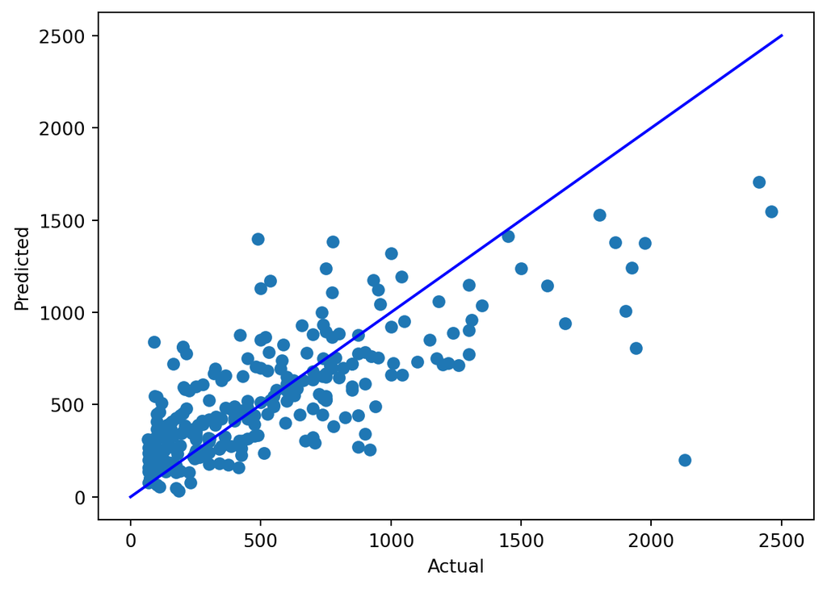

```python
y_pred = elastic_spec_pipeline.predict(X)
plt.scatter(y, y_pred)
x = np.linspace(0, 2500, 100)
z=x
plt.plot(x, z, label='z = x', color='blue')

plt.xlabel("Actual")
plt.ylabel("Predicted")
plt.show()
```

```python
scoresr2 = cross_val_score(elastic_spec_pipeline, X, y, cv=5, scoring='r2')
print(scoresr2.mean())
```

```
0.3591472368390002
```